# 10 Results and Reproducibility Assembly

## 1 Purpose

Step 10 assembles verified outputs from Steps 00–09B into a Results and reproducibility package. It reuses saved estimates under the existing specification without further model estimation, resampling or NCT.

All comparisons remain descriptive unless an explicitly authorised formal test exists. No such cross-wave or education-group significance test is present in the current design. A regularised zero means that an edge was not retained by the selected procedure; it does not prove absence. Retained-edge count and global strength are not treated as ideological constraint.

## 2 Stage 1: locate the project

## 3 Stage 2: optional controlled execution

Ordinary rendering is read-only. The engine and independent audit may be run from a clean R session before rendering, or enabled explicitly through the parameters below.

## 4 Stage 3: completion and validation gates

Step 10 completion status

| Component | Status |
| --- | --- |
| Input inventory and upstream gates | COMPLETE_AND_VALIDATED |
| Primary five-wave result assembly | COMPLETE_AND_VALIDATED |
| Education-group result assembly | COMPLETE_AND_VALIDATED |
| Sensitivity result assembly | COMPLETE_AND_VALIDATED |
| Claim-to-output registry | COMPLETE_AND_VALIDATED |
| Method citation register | COMPLETE_AND_VALIDATED |
| Not-in-Zotero register | COMPLETE_AND_VALIDATED |
| Final table manifest | COMPLETE_AND_VALIDATED |
| Final figure manifest and byte-identity check | COMPLETE_AND_VALIDATED |
| Package/session/renv record | COMPLETE_AND_VALIDATED |
| Step 10 validation | COMPLETE_AND_VALIDATED |
| Independent Step 10 audit | COMPLETE_AND_VALIDATED |
| Dissertation Results prose | NOT_WRITTEN_STEP10_IS_EVIDENCE_ASSEMBLY_ONLY |
| Network re-estimation | NOT_RUN_PROHIBITED_IN_STEP10 |

## 5 Stage 4: current analysis scope

The current researcher-selected working title is:

> Structural Differences in Selected Policy-Attitude Networks across U.S. Election Years: Evidence from ANES Samples, 2004–2024

Expected Influence and Strength are exploratory, not separate confirmatory research questions.

## 6 Stage 5: primary sample and five-wave network descriptors

Verified primary sample and descriptive network summary

| Wave | Analysis_ready_n | Retained_edges | Global_strength_descriptive | Median_percentile_interval_width | Maximum_percentile_interval_width |
| --- | --- | --- | --- | --- | --- |
| 2004 | 789 | 25 | 3.2739 | 0.1508 | 0.2426 |
| 2012 | 4353 | 32 | 3.9598 | 0.0761 | 0.0937 |
| 2016 | 2709 | 32 | 4.0737 | 0.0982 | 0.1338 |
| 2020 | 5390 | 32 | 4.2105 | 0.0712 | 0.0882 |
| 2024 | 3525 | 33 | 4.0968 | 0.0894 | 0.1215 |

All five primary networks produced the saved dense-network warning. Small retained edges therefore require particular caution. Edge count and global strength are reported as descriptive network quantities and are not equated with ideological constraint. The repeated cross-sectional design cannot identify individual change or causal ordering.

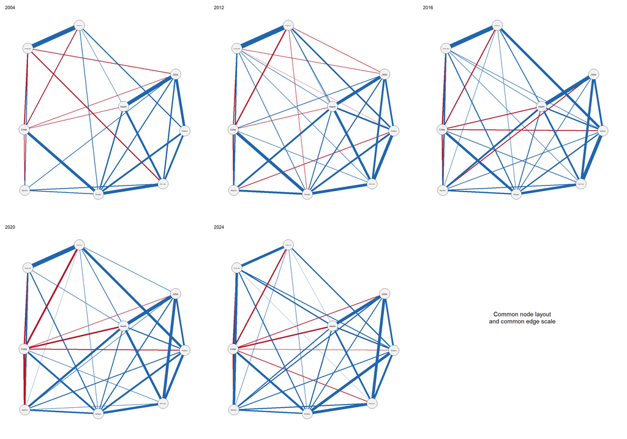

Five primary ANES analysis-sample networks using a common node order, layout and edge scale. Edges are descriptive conditional associations. No NCT or population-design-consistent comparison is implied.

## 7 Stage 6: within-wave edge accuracy

Within-wave edge-accuracy descriptors

| Wave | Retained_edges | Retained_edges_percentile_interval_excluding_zero_audit_only | Median_percentile_interval_width | Maximum_percentile_interval_width |
| --- | --- | --- | --- | --- |
| 2004 | 25 | 9 | 0.1508 | 0.2426 |
| 2012 | 32 | 21 | 0.0761 | 0.0937 |
| 2016 | 32 | 23 | 0.0982 | 0.1338 |
| 2020 | 32 | 24 | 0.0712 | 0.0882 |
| 2024 | 33 | 26 | 0.0894 | 0.1215 |

The percentile-interval columns are retained as precision diagnostics. They are not used as a second rule for accepting or rejecting regularised edges.

## 8 Stage 7: exploratory centrality

Exploratory within-wave centrality and case-dropping stability

| Wave | Highest_Expected_Influence_node | Highest_Expected_Influence | Expected_Influence_CS | Strength_CS |
| --- | --- | --- | --- | --- |
| 2004 | VCF0890 | 1.0223 | 0.7503 | 0.7503 |
| 2012 | VCF0839 | 1.0711 | 0.7501 | 0.7501 |
| 2016 | VCF0839 | 1.0985 | 0.7501 | 0.7501 |
| 2020 | VCF0839 | 1.0058 | 0.7499 | 0.7499 |
| 2024 | VCF0890 | 1.0953 | 0.7501 | 0.7501 |

The CS values reached the highest case-drop proportion examined (approximately 0.75). This supports cautious exploratory within-wave interpretation; it does not establish cross-wave centrality differences, political importance, public salience, causal influence or intervention value.

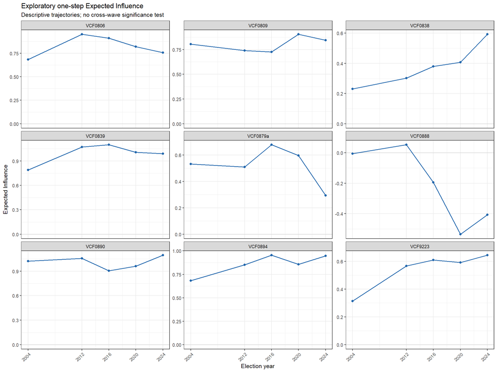

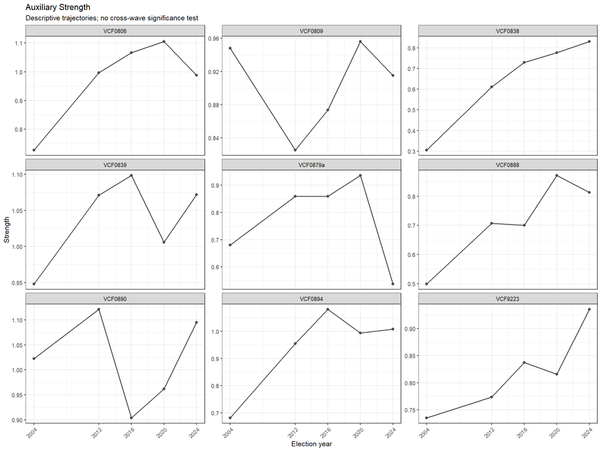

Exploratory Expected Influence and auxiliary Strength. Lines connect repeated cross-sectional wave estimates for display only; no cross-wave centrality significance test was performed.

## 9 Stage 8: education-group result readiness

Education-group within-network result readiness

| Wave | Education_group | N | Retained_edges | Median_percentile_CI_width | Maximum_percentile_CI_width | Sparse_cell_status | Result_readiness |
| --- | --- | --- | --- | --- | --- | --- | --- |
| 2012 | No college degree | 2773 | 28 | 0.0893 | 0.1175 | PASS_WITH_SPARSE_CELL_WARNING | READY_FOR_CAUTIOUS_WITHIN_NETWORK_DESCRIPTION_WITH_LIMITATIONS |
| 2012 | College or advanced degree | 1531 | 28 | 0.1230 | 0.1717 | PASS_WITH_SPARSE_CELL_WARNING | READY_FOR_CAUTIOUS_WITHIN_NETWORK_DESCRIPTION_WITH_LIMITATIONS |
| 2016 | No college degree | 1478 | 28 | 0.1220 | 0.1760 | PASS_WITH_SPARSE_CELL_WARNING | READY_FOR_CAUTIOUS_WITHIN_NETWORK_DESCRIPTION_WITH_LIMITATIONS |
| 2016 | College or advanced degree | 1216 | 31 | 0.1405 | 0.1855 | PASS_WITH_SPARSE_CELL_WARNING | READY_FOR_CAUTIOUS_WITHIN_NETWORK_DESCRIPTION_WITH_LIMITATIONS |
| 2020 | No college degree | 2624 | 30 | 0.0926 | 0.1299 | PASS_WITH_SPARSE_CELL_WARNING | READY_FOR_CAUTIOUS_WITHIN_NETWORK_DESCRIPTION_WITH_LIMITATIONS |
| 2020 | College or advanced degree | 2691 | 33 | 0.1027 | 0.1279 | PASS_WITH_SPARSE_CELL_WARNING | READY_FOR_CAUTIOUS_WITHIN_NETWORK_DESCRIPTION_WITH_LIMITATIONS |
| 2024 | No college degree | 1729 | 34 | 0.1199 | 0.1743 | PASS_WITH_SPARSE_CELL_WARNING | READY_FOR_CAUTIOUS_WITHIN_NETWORK_DESCRIPTION_WITH_LIMITATIONS |
| 2024 | College or advanced degree | 1781 | 32 | 0.1249 | 0.1755 | PASS_WITH_SPARSE_CELL_WARNING | READY_FOR_CAUTIOUS_WITHIN_NETWORK_DESCRIPTION_WITH_LIMITATIONS |

The eight networks may be described separately and cautiously. The analysis did not test whether the two education groups differ statistically. Educational attainment is not interpreted as elite status or as a direct measure of political sophistication.

## 10 Stage 9: sensitivity and joint-robustness evidence

Pre-specified sensitivity and reproducibility evidence

| Evidence_type | Module_or_claim_type | Units | Minimum_edge_weight_correlation | Maximum_edge_weight_correlation | Maximum_absolute_global_strength_difference | Common_retained_sign_reversals | Status | Interpretation |
| --- | --- | --- | --- | --- | --- | --- | --- | --- |
| STEP09_MODULE | S09_D19_MODE__ALL_INTERNET | 4 | 0.9910 | 0.9994 | 0.0871 | 0 | ESTIMABLE_WITH_WARNINGS | DESCRIPTIVE_SPECIFICATION_SENSITIVITY_NOT_MODEL_SELECTION_OR_SIGNIFICANCE |
| STEP09_MODULE | S09_D20A_GAMMA__GAMMA_025 | 5 | 1.0000 | 1.0000 | 0.0000 | 0 | ESTIMABLE_WITH_WARNINGS | DESCRIPTIVE_SPECIFICATION_SENSITIVITY_NOT_MODEL_SELECTION_OR_SIGNIFICANCE |
| STEP09_MODULE | S09_D20A_NO_VCF0839__NO_VCF0839 | 5 | 0.9807 | 0.9865 | NA | 0 | ESTIMABLE_WITH_WARNINGS | DESCRIPTIVE_SPECIFICATION_SENSITIVITY_NOT_MODEL_SELECTION_OR_SIGNIFICANCE |
| STEP09_MODULE | S09_D11__PAIRWISE_AVAILABLE | 5 | 0.9881 | 0.9936 | 0.2762 | 0 | ESTIMABLE_WITH_WARNINGS | DESCRIPTIVE_SPECIFICATION_SENSITIVITY_NOT_MODEL_SELECTION_OR_SIGNIFICANCE |
| STEP09_MODULE | S09_D15_WEIGHT__W_CDF | 5 | 0.9710 | 0.9936 | 0.1800 | 0 | REUSED_VALIDATED_POINT_NETWORK | DESCRIPTIVE_SPECIFICATION_SENSITIVITY_NOT_MODEL_SELECTION_OR_SIGNIFICANCE |
| STEP09_MODULE | S09_D15_WEIGHT__W_POST_COMPAT | 5 | 0.9724 | 0.9902 | 0.1707 | 0 | REUSED_VALIDATED_POINT_NETWORK | DESCRIPTIVE_SPECIFICATION_SENSITIVITY_NOT_MODEL_SELECTION_OR_SIGNIFICANCE |
| STEP09_PRIMARY_CLAIM_AUDIT | EDGE_RETENTION_AND_SIGN | 31 | NA | NA | NA | NA | CHANGED | SENSITIVITY_CLASSIFICATION_NOT_SIGNIFICANCE_OR_EQUIVALENCE |
| STEP09_PRIMARY_CLAIM_AUDIT | EDGE_RETENTION_AND_SIGN | 149 | NA | NA | NA | NA | UNCHANGED | SENSITIVITY_CLASSIFICATION_NOT_SIGNIFICANCE_OR_EQUIVALENCE |
| STEP09B_JOINT_ROBUSTNESS_AUDIT | WAVE_NETWORK_DESCRIPTOR | 15 | NA | NA | NA | NA | DESCRIPTIVE_AUDIT_COMPLETE | REPRODUCIBILITY_CLASSIFICATION_NOT_P_VALUE_SIGNIFICANCE_OR_EQUIVALENCE |
| STEP09B_JOINT_ROBUSTNESS_AUDIT | EDGE_SIGN_AND_RETENTION | 13 | NA | NA | NA | NA | MIXED | REPRODUCIBILITY_CLASSIFICATION_NOT_P_VALUE_SIGNIFICANCE_OR_EQUIVALENCE |
| STEP09B_JOINT_ROBUSTNESS_AUDIT | WAVE_CONTRAST_DIRECTION | 1 | NA | NA | NA | NA | MIXED | REPRODUCIBILITY_CLASSIFICATION_NOT_P_VALUE_SIGNIFICANCE_OR_EQUIVALENCE |
| STEP09B_JOINT_ROBUSTNESS_AUDIT | EDGE_SIGN_AND_RETENTION | 93 | NA | NA | NA | NA | NOT_ROBUST | REPRODUCIBILITY_CLASSIFICATION_NOT_P_VALUE_SIGNIFICANCE_OR_EQUIVALENCE |
| STEP09B_JOINT_ROBUSTNESS_AUDIT | WAVE_CONTRAST_DIRECTION | 6 | NA | NA | NA | NA | NOT_ROBUST | REPRODUCIBILITY_CLASSIFICATION_NOT_P_VALUE_SIGNIFICANCE_OR_EQUIVALENCE |
| STEP09B_JOINT_ROBUSTNESS_AUDIT | EDGE_SIGN_AND_RETENTION | 74 | NA | NA | NA | NA | ROBUST | REPRODUCIBILITY_CLASSIFICATION_NOT_P_VALUE_SIGNIFICANCE_OR_EQUIVALENCE |
| STEP09B_JOINT_ROBUSTNESS_AUDIT | WAVE_CONTRAST_DIRECTION | 3 | NA | NA | NA | NA | ROBUST | REPRODUCIBILITY_CLASSIFICATION_NOT_P_VALUE_SIGNIFICANCE_OR_EQUIVALENCE |

Sensitivity labels summarise whether descriptive results reproduced under the pre-specified alternatives. `ROBUST`, `MIXED`, `NOT_ROBUST`, `UNCHANGED` and `CHANGED` are not p-values, significance tests or equivalence tests.

## 11 Stage 10: Results claim-to-output control

First 20 rows of the claim-to-output registry

| Claim_ID | Research_question | Analysis_scope | Claim_type | Value_or_status | Permitted_wording | Required_qualification | Evidence_file | Evidence_columns | Validation_status | Method_reference_ids | Supervisor_confirmation |
| --- | --- | --- | --- | --- | --- | --- | --- | --- | --- | --- | --- |
| RQ1_WAVE_2004_NETWORK_DESCRIPTOR | RQ1 | Overall ANES analysis sample, 2004 | DESCRIPTIVE_NETWORK_DESCRIPTOR | N=789; retained_edges=25; global_strength=3.2739 | Describe the saved sample-level conditional-association network. | Dense-network warning; edge count and global strength are not ideological constraint; no significance test. | 10_sample_primary_summary.csv | Analysis_ready_n; Retained_edges; Global_strength_descriptive; Dense_network_warning | READY_WITH_METHOD_LIMITATIONS | M01;M02;M03;D01 | HISTORICAL_INTERPRETATION_SCOPE_ADVISED |
| RQ1_WAVE_2004_EDGE_ACCURACY | RQ1 | Within-wave edge accuracy, 2004 | EDGE_PRECISION | median_CI_width=0.1508; maximum_CI_width=0.2426 | Describe uncertainty width and bootstrap diagnostics. | Whether a bootstrap percentile interval contains zero is audit information, not a second edge-selection threshold. | 10_sample_primary_summary.csv | Median_percentile_interval_width; Maximum_percentile_interval_width | READY | M02;M03 | NO |
| EXPLORATORY_WAVE_2004_CENTRALITY | EXPLORATORY_NOT_FORMAL_RQ | Within-wave centrality, 2004 | EXPLORATORY_EXPECTED_INFLUENCE | highest_EI_node=VCF0890; EI_CS_at_max_examined_drop=0.7503 | Cautiously describe signed connectivity within the selected node set. | No causal importance, public salience, cross-wave centrality test, or intervention claim. | 10_sample_primary_summary.csv | Highest_Expected_Influence_node; Highest_Expected_Influence; Expected_Influence_CS | EXPLORATORY_READY | M02;M04;M05 | NO |
| RQ1_WAVE_2012_NETWORK_DESCRIPTOR | RQ1 | Overall ANES analysis sample, 2012 | DESCRIPTIVE_NETWORK_DESCRIPTOR | N=4353; retained_edges=32; global_strength=3.9598 | Describe the saved sample-level conditional-association network. | Dense-network warning; edge count and global strength are not ideological constraint; no significance test. | 10_sample_primary_summary.csv | Analysis_ready_n; Retained_edges; Global_strength_descriptive; Dense_network_warning | READY_WITH_METHOD_LIMITATIONS | M01;M02;M03;D01 | NO |
| RQ1_WAVE_2012_EDGE_ACCURACY | RQ1 | Within-wave edge accuracy, 2012 | EDGE_PRECISION | median_CI_width=0.0761; maximum_CI_width=0.0937 | Describe uncertainty width and bootstrap diagnostics. | Whether a bootstrap percentile interval contains zero is audit information, not a second edge-selection threshold. | 10_sample_primary_summary.csv | Median_percentile_interval_width; Maximum_percentile_interval_width | READY | M02;M03 | NO |
| EXPLORATORY_WAVE_2012_CENTRALITY | EXPLORATORY_NOT_FORMAL_RQ | Within-wave centrality, 2012 | EXPLORATORY_EXPECTED_INFLUENCE | highest_EI_node=VCF0839; EI_CS_at_max_examined_drop=0.7501 | Cautiously describe signed connectivity within the selected node set. | No causal importance, public salience, cross-wave centrality test, or intervention claim. | 10_sample_primary_summary.csv | Highest_Expected_Influence_node; Highest_Expected_Influence; Expected_Influence_CS | EXPLORATORY_READY | M02;M04;M05 | NO |
| RQ1_WAVE_2016_NETWORK_DESCRIPTOR | RQ1 | Overall ANES analysis sample, 2016 | DESCRIPTIVE_NETWORK_DESCRIPTOR | N=2709; retained_edges=32; global_strength=4.0737 | Describe the saved sample-level conditional-association network. | Dense-network warning; edge count and global strength are not ideological constraint; no significance test. | 10_sample_primary_summary.csv | Analysis_ready_n; Retained_edges; Global_strength_descriptive; Dense_network_warning | READY_WITH_METHOD_LIMITATIONS | M01;M02;M03;D01 | NO |
| RQ1_WAVE_2016_EDGE_ACCURACY | RQ1 | Within-wave edge accuracy, 2016 | EDGE_PRECISION | median_CI_width=0.0982; maximum_CI_width=0.1338 | Describe uncertainty width and bootstrap diagnostics. | Whether a bootstrap percentile interval contains zero is audit information, not a second edge-selection threshold. | 10_sample_primary_summary.csv | Median_percentile_interval_width; Maximum_percentile_interval_width | READY | M02;M03 | NO |
| EXPLORATORY_WAVE_2016_CENTRALITY | EXPLORATORY_NOT_FORMAL_RQ | Within-wave centrality, 2016 | EXPLORATORY_EXPECTED_INFLUENCE | highest_EI_node=VCF0839; EI_CS_at_max_examined_drop=0.7501 | Cautiously describe signed connectivity within the selected node set. | No causal importance, public salience, cross-wave centrality test, or intervention claim. | 10_sample_primary_summary.csv | Highest_Expected_Influence_node; Highest_Expected_Influence; Expected_Influence_CS | EXPLORATORY_READY | M02;M04;M05 | NO |
| RQ1_WAVE_2020_NETWORK_DESCRIPTOR | RQ1 | Overall ANES analysis sample, 2020 | DESCRIPTIVE_NETWORK_DESCRIPTOR | N=5390; retained_edges=32; global_strength=4.2105 | Describe the saved sample-level conditional-association network. | Dense-network warning; edge count and global strength are not ideological constraint; no significance test. | 10_sample_primary_summary.csv | Analysis_ready_n; Retained_edges; Global_strength_descriptive; Dense_network_warning | READY_WITH_METHOD_LIMITATIONS | M01;M02;M03;D01 | NO |
| RQ1_WAVE_2020_EDGE_ACCURACY | RQ1 | Within-wave edge accuracy, 2020 | EDGE_PRECISION | median_CI_width=0.0712; maximum_CI_width=0.0882 | Describe uncertainty width and bootstrap diagnostics. | Whether a bootstrap percentile interval contains zero is audit information, not a second edge-selection threshold. | 10_sample_primary_summary.csv | Median_percentile_interval_width; Maximum_percentile_interval_width | READY | M02;M03 | NO |
| EXPLORATORY_WAVE_2020_CENTRALITY | EXPLORATORY_NOT_FORMAL_RQ | Within-wave centrality, 2020 | EXPLORATORY_EXPECTED_INFLUENCE | highest_EI_node=VCF0839; EI_CS_at_max_examined_drop=0.7499 | Cautiously describe signed connectivity within the selected node set. | No causal importance, public salience, cross-wave centrality test, or intervention claim. | 10_sample_primary_summary.csv | Highest_Expected_Influence_node; Highest_Expected_Influence; Expected_Influence_CS | EXPLORATORY_READY | M02;M04;M05 | NO |
| RQ1_WAVE_2024_NETWORK_DESCRIPTOR | RQ1 | Overall ANES analysis sample, 2024 | DESCRIPTIVE_NETWORK_DESCRIPTOR | N=3525; retained_edges=33; global_strength=4.0968 | Describe the saved sample-level conditional-association network. | Dense-network warning; edge count and global strength are not ideological constraint; no significance test. | 10_sample_primary_summary.csv | Analysis_ready_n; Retained_edges; Global_strength_descriptive; Dense_network_warning | READY_WITH_METHOD_LIMITATIONS | M01;M02;M03;D01 | HISTORICAL_INTERPRETATION_SCOPE_ADVISED |
| RQ1_WAVE_2024_EDGE_ACCURACY | RQ1 | Within-wave edge accuracy, 2024 | EDGE_PRECISION | median_CI_width=0.0894; maximum_CI_width=0.1215 | Describe uncertainty width and bootstrap diagnostics. | Whether a bootstrap percentile interval contains zero is audit information, not a second edge-selection threshold. | 10_sample_primary_summary.csv | Median_percentile_interval_width; Maximum_percentile_interval_width | READY | M02;M03 | NO |
| EXPLORATORY_WAVE_2024_CENTRALITY | EXPLORATORY_NOT_FORMAL_RQ | Within-wave centrality, 2024 | EXPLORATORY_EXPECTED_INFLUENCE | highest_EI_node=VCF0890; EI_CS_at_max_examined_drop=0.7501 | Cautiously describe signed connectivity within the selected node set. | No causal importance, public salience, cross-wave centrality test, or intervention claim. | 10_sample_primary_summary.csv | Highest_Expected_Influence_node; Highest_Expected_Influence; Expected_Influence_CS | EXPLORATORY_READY | M02;M04;M05 | NO |
| RQ2_2012_NO_COLLEGE_DEGREE | RQ2 | 2012, No college degree | DESCRIPTIVE_EDUCATION_NETWORK | N=2773; retained_edges=28 | Describe edges and relational configuration within this education-group network. | No formal between-group inference; education is not elite status or a direct measure of political sophistication. | 10_education_summary.csv | N; Retained_edges; Result_readiness; Permitted_scope | READY_WITHIN_NETWORK_ONLY | M01;M02;M03;D01 | RQ2_EXACT_WORDING_STILL_TO_BE_ENTERED_IN_DECISION_LOG |
| RQ2_2012_COLLEGE_OR_ADVANCED | RQ2 | 2012, College or advanced degree | DESCRIPTIVE_EDUCATION_NETWORK | N=1531; retained_edges=28 | Describe edges and relational configuration within this education-group network. | No formal between-group inference; education is not elite status or a direct measure of political sophistication. | 10_education_summary.csv | N; Retained_edges; Result_readiness; Permitted_scope | READY_WITHIN_NETWORK_ONLY | M01;M02;M03;D01 | RQ2_EXACT_WORDING_STILL_TO_BE_ENTERED_IN_DECISION_LOG |
| RQ2_2016_NO_COLLEGE_DEGREE | RQ2 | 2016, No college degree | DESCRIPTIVE_EDUCATION_NETWORK | N=1478; retained_edges=28 | Describe edges and relational configuration within this education-group network. | No formal between-group inference; education is not elite status or a direct measure of political sophistication. | 10_education_summary.csv | N; Retained_edges; Result_readiness; Permitted_scope | READY_WITHIN_NETWORK_ONLY | M01;M02;M03;D01 | RQ2_EXACT_WORDING_STILL_TO_BE_ENTERED_IN_DECISION_LOG |
| RQ2_2016_COLLEGE_OR_ADVANCED | RQ2 | 2016, College or advanced degree | DESCRIPTIVE_EDUCATION_NETWORK | N=1216; retained_edges=31 | Describe edges and relational configuration within this education-group network. | No formal between-group inference; education is not elite status or a direct measure of political sophistication. | 10_education_summary.csv | N; Retained_edges; Result_readiness; Permitted_scope | READY_WITHIN_NETWORK_ONLY | M01;M02;M03;D01 | RQ2_EXACT_WORDING_STILL_TO_BE_ENTERED_IN_DECISION_LOG |
| RQ2_2020_NO_COLLEGE_DEGREE | RQ2 | 2020, No college degree | DESCRIPTIVE_EDUCATION_NETWORK | N=2624; retained_edges=30 | Describe edges and relational configuration within this education-group network. | No formal between-group inference; education is not elite status or a direct measure of political sophistication. | 10_education_summary.csv | N; Retained_edges; Result_readiness; Permitted_scope | READY_WITHIN_NETWORK_ONLY | M01;M02;M03;D01 | RQ2_EXACT_WORDING_STILL_TO_BE_ENTERED_IN_DECISION_LOG |

The full registry remains a machine-readable audit file. Dissertation prose must be drafted later from these verified records rather than from memory or a chat summary.

## 12 Stage 11: method citations and Zotero gaps

Step 10 method and data-source citation register

| Reference_ID | Authors | Year | Title | Role_in_Step10 | Full_text_or_official_source_status | Zotero_status |
| --- | --- | --- | --- | --- | --- | --- |
| M01 | Epskamp and Fried | 2018 | A Tutorial on Regularized Partial Correlation Networks | Conditional-edge, ordinal-polychoric, EBICglasso and regularisation interpretation | LOCAL_FULL_TEXT_INSPECTED | IN_ZOTERO_DUPLICATE_RECORDS_PRESENT |
| M02 | Epskamp, Borsboom and Fried | 2018 | Estimating Psychological Networks and Their Accuracy: A Tutorial Paper | Edge-accuracy bootstrap, case-dropping stability and CS interpretation | LOCAL_FULL_TEXT_INSPECTED | IN_ZOTERO |
| M03 | Burger et al. | 2023 | Reporting Standards for Psychological Network Analyses in Cross-Sectional Data | Transparent reporting, comparable figures, software/defaults and limitation reporting | LOCAL_FULL_TEXT_INSPECTED | IN_ZOTERO_DUPLICATE_RECORDS_PRESENT |
| M04 | Bringmann et al. | 2019 | What Do Centrality Measures Measure in Psychological Networks? | Centrality interpretation boundary | LOCAL_FULL_TEXT_INSPECTED | IN_ZOTERO |
| M05 | Robinaugh, Millner and McNally | 2016 | Identifying Highly Influential Nodes in the Complicated Grief Network | Original one-step Expected Influence definition; used only for definition | FULL_TEXT_AVAILABLE_VIA_PMC_AND_INSPECTED_THIS_PROJECT;_LOCAL_ZOTERO_PDF_ABSENT | NOT_IN_ZOTERO |
| S01 | Epskamp, Cramer, Waldorp, Schmittmann and Borsboom | 2012 | qgraph: Network Visualizations of Relationships in Psychometric Data | qgraph software citation | LOCAL_PACKAGE_CITATION_INSPECTED | NOT_IN_ZOTERO |
| S02 | bootnet package documentation | VERIFICATION REQUIRED | bootnet package documentation and citation metadata | bootnet implementation record; theory is cited to Epskamp et al. 2018 | LOCAL_PACKAGE_CITATION_INSPECTED | NOT_IN_ZOTERO_AS_SOFTWARE_RESOURCE |
| D01 | American National Election Studies | 2026 | ANES Time Series Cumulative Data File 1948–2024 documentation | Data release, harmonisation and repeated-cross-section documentation | LOCAL_OFFICIAL_DOCUMENTATION_AVAILABLE | NOT_IN_ZOTERO |

Sources used in Step 10 that are not currently recorded in Zotero

| Reference_ID | Authors | Year | Title | Zotero_status | Verification_note |
| --- | --- | --- | --- | --- | --- |
| M05 | Robinaugh, Millner and McNally | 2016 | Identifying Highly Influential Nodes in the Complicated Grief Network | NOT_IN_ZOTERO | Do not treat lack of a Zotero attachment as lack of accessible full text. |
| S01 | Epskamp, Cramer, Waldorp, Schmittmann and Borsboom | 2012 | qgraph: Network Visualizations of Relationships in Psychometric Data | NOT_IN_ZOTERO | Verified from the installed qgraph CITATION file. |
| S02 | bootnet package documentation | VERIFICATION REQUIRED | bootnet package documentation and citation metadata | NOT_IN_ZOTERO_AS_SOFTWARE_RESOURCE | Record version and interface only; do not substitute package documentation for the method paper. |
| D01 | American National Election Studies | 2026 | ANES Time Series Cumulative Data File 1948–2024 documentation | NOT_IN_ZOTERO | Official operational data source, not a peer-reviewed method article. |

The core network-method claims are supported by Epskamp and Fried (2018), Epskamp, Borsboom and Fried (2018), Burger et al. (2023), and Bringmann et al. (2019), all of which have inspected local full text. The original Expected Influence definition is traced to Robinaugh, Millner and McNally (2016); the full text was inspected through an accessible PMC copy, but no local Zotero PDF is present. The qgraph software citation and official ANES documentation are also explicitly marked as absent from Zotero.

## 13 Stage 12: reproducibility package

Software and package-version manifest

| Software | Version_locked | Version_loaded_for_Step10 | Role | Step10_model_execution |
| --- | --- | --- | --- | --- |
| R | 4.5.2 | 4.5.2 | Analysis environment | NO |
| qgraph | 1.10.1 | 1.10.1 | Primary network estimation and visualisation in earlier validated steps | NO |
| bootnet | 1.9.1 | 1.9.1 | Bootstrap accuracy and stability in earlier validated steps | NO |
| psych | 2.6.5 | 2.6.5 | Polychoric correlations in earlier validated steps | NO |
| lavaan | 0.7-2 | 0.7.2 | Correlation support in earlier validated steps | NO |
| digest | 0.6.39 | 0.6.39 | SHA-256 hashing in Step 10 | NO |
| knitr | 1.51 | 1.51 | Step 10 report rendering | NO |
| rmarkdown | 2.31 | 2.31 | Step 10 report rendering | NO |
| renv | 1.2.0 | 1.2.0 | Project dependency lock | NO |

Reproducibility-material status

| Component | Status | Evidence | Limitation |
| --- | --- | --- | --- |
| Source data documentation | AVAILABLE_READ_ONLY | Official ANES documentation and project source inventory | ANES access and source-version requirements still apply. |
| Derived analysis-ready data | AVAILABLE | data/processed and data/audit | Raw ANES data are not redistributed. |
| Ordered preprocessing notebooks | AVAILABLE | notebooks/00–06 and their rendered reports | Step 10 does not rerun Steps 00–09B. |
| Primary point-network objects | AVAILABLE_VALIDATED | outputs/models/formal | All primary networks carry a dense-network warning. |
| Edge bootstrap objects | AVAILABLE_VALIDATED_1000_PER_WAVE | outputs/models/formal and 07A validation | Intervals are precision evidence, not edge-selection tests. |
| Centrality case-drop objects | AVAILABLE_VALIDATED_1000_PER_WAVE | outputs/models/formal and 07B validation | Centrality remains exploratory. |
| Education network and bootstrap objects | AVAILABLE_VALIDATED_1000_PER_GROUP | outputs/models/formal and 08B/08C validation | No education-group significance test. |
| Sensitivity objects | AVAILABLE_VALIDATED | outputs/models/sensitivity and 09/09B validation | Robustness labels are not p-values or equivalence tests. |
| Dependency lock | AVAILABLE_HASHED | renv.lock | A current renv status snapshot is reported separately. |
| Package manifest | CREATED | 10_package_manifest.csv | Package-version fields should be checked again at final submission. |
| Session information | CREATED | outputs/logs/10_sessionInfo.txt | Operating-system and locale warnings may be environment-specific. |
| renv status snapshot | COMPLETED | outputs/logs/10_renv_status.txt | Any recorded issue must be resolved before final archive freeze. |
| Random seeds | AVAILABLE_IN_PRIOR_OUTPUTS_AND_SCRIPTS | Prior seed manifests and executable notebooks | No new random process was executed in Step 10. |
| Claim-to-output registry | CREATED | 10_result_claim_registry.csv | Registry is an audit aid, not dissertation prose. |
| Input and output SHA-256 inventories | CREATED | 10_input_inventory.csv; 10_output_hash_inventory.csv | Hashes attest file identity, not substantive validity. |

Final figure manifest

| Figure_ID | Final_path | Figure_role | Bytes | Byte_identical | Required_caption_boundary |
| --- | --- | --- | --- | --- | --- |
| FIG10_01 | D:/ANES_code/ANES_dissertation/outputs/figures/final/10_08_overall_networks_five_wave_panel.png | MAIN_CANDIDATE_OVERALL_NETWORK_PANEL | 129003 | TRUE | Repeated cross-sectional ANES analysis samples; descriptive conditional associations; common layout and scale; no NCT. |
| FIG10_02 | D:/ANES_code/ANES_dissertation/outputs/figures/final/10_07A_edge_accuracy_2004.png | SUPPLEMENTARY_EDGE_ACCURACY | 46858 | TRUE | Within-wave percentile uncertainty; interval inclusion of zero is not a second edge-selection rule. |
| FIG10_03 | D:/ANES_code/ANES_dissertation/outputs/figures/final/10_07A_edge_accuracy_2012.png | SUPPLEMENTARY_EDGE_ACCURACY | 46829 | TRUE | Within-wave percentile uncertainty; interval inclusion of zero is not a second edge-selection rule. |
| FIG10_04 | D:/ANES_code/ANES_dissertation/outputs/figures/final/10_07A_edge_accuracy_2016.png | SUPPLEMENTARY_EDGE_ACCURACY | 47517 | TRUE | Within-wave percentile uncertainty; interval inclusion of zero is not a second edge-selection rule. |
| FIG10_05 | D:/ANES_code/ANES_dissertation/outputs/figures/final/10_07A_edge_accuracy_2020.png | SUPPLEMENTARY_EDGE_ACCURACY | 46626 | TRUE | Within-wave percentile uncertainty; interval inclusion of zero is not a second edge-selection rule. |
| FIG10_06 | D:/ANES_code/ANES_dissertation/outputs/figures/final/10_07A_edge_accuracy_2024.png | SUPPLEMENTARY_EDGE_ACCURACY | 47382 | TRUE | Within-wave percentile uncertainty; interval inclusion of zero is not a second edge-selection rule. |
| FIG10_07 | D:/ANES_code/ANES_dissertation/outputs/figures/final/10_08_expected_influence_over_time.png | EXPLORATORY_CENTRALITY_CANDIDATE | 60360 | TRUE | Exploratory Expected Influence only; no cross-wave significance or causal-importance claim. |
| FIG10_08 | D:/ANES_code/ANES_dissertation/outputs/figures/final/10_08_strength_over_time.png | EXPLORATORY_CENTRALITY_AUXILIARY | 70374 | TRUE | Auxiliary Strength only; no cross-wave significance or causal-importance claim. |
| FIG10_09 | D:/ANES_code/ANES_dissertation/outputs/figures/final/10_08C_education_network_2012__no_college_degree.png | SUPPLEMENTARY_EDUCATION_WITHIN_NETWORK | 109087 | TRUE | Within-group descriptive network only; common layout and scale; no between-group inference. |
| FIG10_10 | D:/ANES_code/ANES_dissertation/outputs/figures/final/10_08C_education_network_2012__college_or_advanced.png | SUPPLEMENTARY_EDUCATION_WITHIN_NETWORK | 111701 | TRUE | Within-group descriptive network only; common layout and scale; no between-group inference. |
| FIG10_11 | D:/ANES_code/ANES_dissertation/outputs/figures/final/10_08C_education_network_2016__no_college_degree.png | SUPPLEMENTARY_EDUCATION_WITHIN_NETWORK | 109496 | TRUE | Within-group descriptive network only; common layout and scale; no between-group inference. |
| FIG10_12 | D:/ANES_code/ANES_dissertation/outputs/figures/final/10_08C_education_network_2016__college_or_advanced.png | SUPPLEMENTARY_EDUCATION_WITHIN_NETWORK | 108985 | TRUE | Within-group descriptive network only; common layout and scale; no between-group inference. |
| FIG10_13 | D:/ANES_code/ANES_dissertation/outputs/figures/final/10_08C_education_network_2020__no_college_degree.png | SUPPLEMENTARY_EDUCATION_WITHIN_NETWORK | 106568 | TRUE | Within-group descriptive network only; common layout and scale; no between-group inference. |
| FIG10_14 | D:/ANES_code/ANES_dissertation/outputs/figures/final/10_08C_education_network_2020__college_or_advanced.png | SUPPLEMENTARY_EDUCATION_WITHIN_NETWORK | 116691 | TRUE | Within-group descriptive network only; common layout and scale; no between-group inference. |
| FIG10_15 | D:/ANES_code/ANES_dissertation/outputs/figures/final/10_08C_education_network_2024__no_college_degree.png | SUPPLEMENTARY_EDUCATION_WITHIN_NETWORK | 114070 | TRUE | Within-group descriptive network only; common layout and scale; no between-group inference. |
| FIG10_16 | D:/ANES_code/ANES_dissertation/outputs/figures/final/10_08C_education_network_2024__college_or_advanced.png | SUPPLEMENTARY_EDUCATION_WITHIN_NETWORK | 114632 | TRUE | Within-group descriptive network only; common layout and scale; no between-group inference. |
| FIG10_17 | D:/ANES_code/ANES_dissertation/outputs/figures/final/10_08C_education_edge_accuracy_2012__no_college_degree.png | SUPPLEMENTARY_EDUCATION_EDGE_ACCURACY | 102254 | TRUE | Within-group edge uncertainty only; no between-group inference and no second edge-selection rule. |
| FIG10_18 | D:/ANES_code/ANES_dissertation/outputs/figures/final/10_08C_education_edge_accuracy_2012__college_or_advanced.png | SUPPLEMENTARY_EDUCATION_EDGE_ACCURACY | 103316 | TRUE | Within-group edge uncertainty only; no between-group inference and no second edge-selection rule. |
| FIG10_19 | D:/ANES_code/ANES_dissertation/outputs/figures/final/10_08C_education_edge_accuracy_2016__no_college_degree.png | SUPPLEMENTARY_EDUCATION_EDGE_ACCURACY | 102572 | TRUE | Within-group edge uncertainty only; no between-group inference and no second edge-selection rule. |
| FIG10_20 | D:/ANES_code/ANES_dissertation/outputs/figures/final/10_08C_education_edge_accuracy_2016__college_or_advanced.png | SUPPLEMENTARY_EDUCATION_EDGE_ACCURACY | 103581 | TRUE | Within-group edge uncertainty only; no between-group inference and no second edge-selection rule. |
| FIG10_21 | D:/ANES_code/ANES_dissertation/outputs/figures/final/10_08C_education_edge_accuracy_2020__no_college_degree.png | SUPPLEMENTARY_EDUCATION_EDGE_ACCURACY | 102080 | TRUE | Within-group edge uncertainty only; no between-group inference and no second edge-selection rule. |
| FIG10_22 | D:/ANES_code/ANES_dissertation/outputs/figures/final/10_08C_education_edge_accuracy_2020__college_or_advanced.png | SUPPLEMENTARY_EDUCATION_EDGE_ACCURACY | 103033 | TRUE | Within-group edge uncertainty only; no between-group inference and no second edge-selection rule. |
| FIG10_23 | D:/ANES_code/ANES_dissertation/outputs/figures/final/10_08C_education_edge_accuracy_2024__no_college_degree.png | SUPPLEMENTARY_EDUCATION_EDGE_ACCURACY | 102147 | TRUE | Within-group edge uncertainty only; no between-group inference and no second edge-selection rule. |
| FIG10_24 | D:/ANES_code/ANES_dissertation/outputs/figures/final/10_08C_education_edge_accuracy_2024__college_or_advanced.png | SUPPLEMENTARY_EDUCATION_EDGE_ACCURACY | 103281 | TRUE | Within-group edge uncertainty only; no between-group inference and no second edge-selection rule. |

The final figure copies are byte-identical to the validated Step 07A/08/08C sources. Step 10 records a package manifest, `sessionInfo()`, `renv` status, input hashes, output hashes and an independent recalculation audit. Raw ANES data are not redistributed.

The recorded `renv::status()` snapshot reports that the project library and lockfile are synchronized. The saved numerical outputs also passed independent recalculation.

## 14 Stage 13: independent audit result

Independent Step 10 audit

| Check | Passed | Evidence |
| --- | --- | --- |
| Independent recalculation matches every listed core value | TRUE | 10_independent_recalculation.csv |
| Primary wave set is exactly 2004, 2012, 2016, 2020 and 2024 | TRUE | 10_sample_primary_summary.csv |
| Primary N, retained-edge and global-strength values match source outputs | TRUE | Direct source/Step10 join |
| Edge-accuracy widths match source outputs | TRUE | 07A_edge_accuracy_by_wave.csv compared with 10_sample_primary_summary.csv |
| Expected Influence and Strength each have five CS records | TRUE | 08_overall_centrality_stability.csv |
| All centrality records retain exploratory interpretation boundaries | TRUE | 08_overall_centrality_stability.csv |
| Education result contains exactly eight expected group-wave rows | TRUE | 08C_education_result_readiness.csv compared with 10_education_summary.csv |
| Education result contains no between-group inferential output | TRUE | 10_education_summary.csv |
| Step 09 claim counts are 149 unchanged and 31 changed | TRUE | 09_primary_claim_robustness_summary.csv compared with 10_sensitivity_summary.csv |
| Step 09B edge counts are 74 robust, 13 mixed and 93 not robust | TRUE | 09B_claim_robustness.csv compared with 10_sensitivity_summary.csv |
| Step 09B contrast counts are 3 robust, 1 mixed and 6 not robust | TRUE | 09B_claim_robustness.csv compared with 10_sensitivity_summary.csv |
| Every final figure exists, is non-empty and SHA-identical to its source | TRUE | 10_figure_manifest.csv and independent hashes |
| Every inventoried Step 10 output hash still matches | TRUE | 10_output_hash_inventory.csv |
| Every Step 10 first-pass validation check passed | TRUE | 10_validation.csv |
| Method citation register contains Zotero-status and evidence-status fields | TRUE | 10_method_citation_register.csv |
| Every not-in-Zotero row is a subset of the citation register | TRUE | 10_references_not_in_zotero.csv |
| No visible creation-date or time column exists | TRUE | All 10_ CSV headers |
| No 2008 result appears in Step 10 summaries or claim registry | TRUE | 10_sample_primary_summary.csv; 10_education_summary.csv; 10_result_claim_registry.csv |
| No prohibited model, bootstrap, correlation-estimation or NCT call appears | TRUE | Static scan of Step 10 engine and Rmd |
| Completion table correctly keeps dissertation prose and model rerun outside Step 10 | TRUE | 10_completion_status.csv |

Every check above must remain `TRUE` before this report is treated as current. Re-rendering the report ordinarily reads the saved audit package and performs no new model computation.